# PML_Project

Daniel Jaeger

23 December 2015

Using various activity data cited in the report, we will build a model that predicts which exercise a subject is performing. The data we are using contains information on movements recored by various wearable measurement instruments such as armbands, gloves, belts, and dumbell sensors. The goal is to predict which exercise is being performed based on the data. Specifically from the data summary, “Six young health participants were asked to perform one set of 10 repetitions of the Unilateral Dumbbell Biceps Curl in five different fashions: exactly according to the specification (Class A), throwing the elbows to the front (Class B), lifting the dumbbell only halfway (Class C), lowering the dumbbell only halfway (Class D) and throwing the hips to the front (Class E).”

First, we load the data and initialize the caret package in R:

```r
library(caret)
train_orig <- read.csv('pml-training.csv')
test_orig <- read.csv('pml-testing.csv')
```

Now, we proceed to clean the data

```r
## grab numeric data
train_v1 <- train_orig[,8:159]
test_v1 <- test_orig[,8:159]

## make all values numeric
train_v1 <- data.frame(sapply(train_v1, as.numeric))
test_v1 <- data.frame(sapply(test_v1, as.numeric))

## modify NA's so they are zero
train_v1[is.na(train_v1)] <- 0
test_v1[is.na(test_v1)] <- 0
```

The caret package contains some useful tools to filter out irrelevant data. Specifically, we use nearZeroVar and findCorrelation. nearZeroVar filters out fields that have few unique values or a low variance. findCorrelation searches through a correlation matrix and returns a vector of integers corresponding to columns to remove to reduce pair-wise correlations.

```r
## get rid of variables at near zero variance
nearZero <- nearZeroVar(train_v1)
train_v1 <- train_v1[,-nearZero]
test_v1 <- test_v1[,-nearZero]

##adjust for correlation
cor <- findCorrelation(cor(train_v1))
train_v1 <- train_v1[,-cor]
test_v1 <- test_v1[,-cor]
```

Next we include the user variable, which is non-numeric. This may have some predictive value. We also bring in the classe variable, which we are trying to predict.

```r
## include user variable
user_train <- as.factor(train_orig$user_name)
user_test <- as.factor(test_orig$user_name)

## include classe variable
classe_train <- as.factor(train_orig[,160])

## apply cbind
train_v1 <- cbind(train_v1, user_train, classe_train)
test_v1 <- cbind(test_v1, user_test)
colnames(test_v1) [46] <- "user_train"
```

Now we partition our larger dataset into a train and test. We will use a 75/25 split.

```r
## create data partition for testing
set.seed(100)
trainrows <- createDataPartition(y=classe_train, p=.75, list=FALSE)
train_v2 <- train_v1[trainrows,]
test_v2 <- train_v1[-trainrows,]
```

```r
## fit model and view results
control <- trainControl(method = "repeatedcv", repeats = 2)
modfit <- train(classe_train ~ ., data = train_v2, method = "rf", tuneLength=1)
modfit
```

```
## Random Forest
##
## 14718 samples
##    46 predictor
##     5 classes: 'A', 'B', 'C', 'D', 'E'
##
## No pre-processing
## Resampling: Bootstrapped (25 reps)
##
## Summary of sample sizes: 14718, 14718, 14718, 14718, 14718, 14718, ...
##
## Resampling results
##
##   Accuracy   Kappa      Accuracy SD  Kappa SD
##   0.9911203  0.9887631  0.00130727   0.001652687
##
## Tuning parameter 'mtry' was held constant at a value of 16
##
```

We will now test our model on the larger testing set and produce our output of 20 predictors as requested by this assignment.

```r
## test model
pred <- predict(modfit, test_v2)
confusionMatrix(test_v2$classe_train, pred)
```

```
## Confusion Matrix and Statistics
##
##           Reference
## Prediction    A    B    C    D    E
##          A 1393    2    0    0    0
##          B    5  940    4    0    0
##          C    0    4  848    3    0
##          D    0    0    6  798    0
##          E    0    0    1    2  898
##
## Overall Statistics
##
##                Accuracy : 0.9945
##                  95% CI : (0.992, 0.9964)
##     No Information Rate : 0.2851
##     P-Value [Acc > NIR] : < 2.2e-16
##
##                   Kappa : 0.993
##  Mcnemar's Test P-Value : NA
##
## Statistics by Class:
##
##                      Class: A Class: B Class: C Class: D Class: E
## Sensitivity            0.9964   0.9937   0.9872   0.9938   1.0000
## Specificity            0.9994   0.9977   0.9983   0.9985   0.9993
## Pos Pred Value         0.9986   0.9905   0.9918   0.9925   0.9967
## Neg Pred Value         0.9986   0.9985   0.9973   0.9988   1.0000
## Prevalence             0.2851   0.1929   0.1752   0.1637   0.1831
## Detection Rate         0.2841   0.1917   0.1729   0.1627   0.1831
## Detection Prevalence   0.2845   0.1935   0.1743   0.1639   0.1837
## Balanced Accuracy      0.9979   0.9957   0.9927   0.9962   0.9996
```

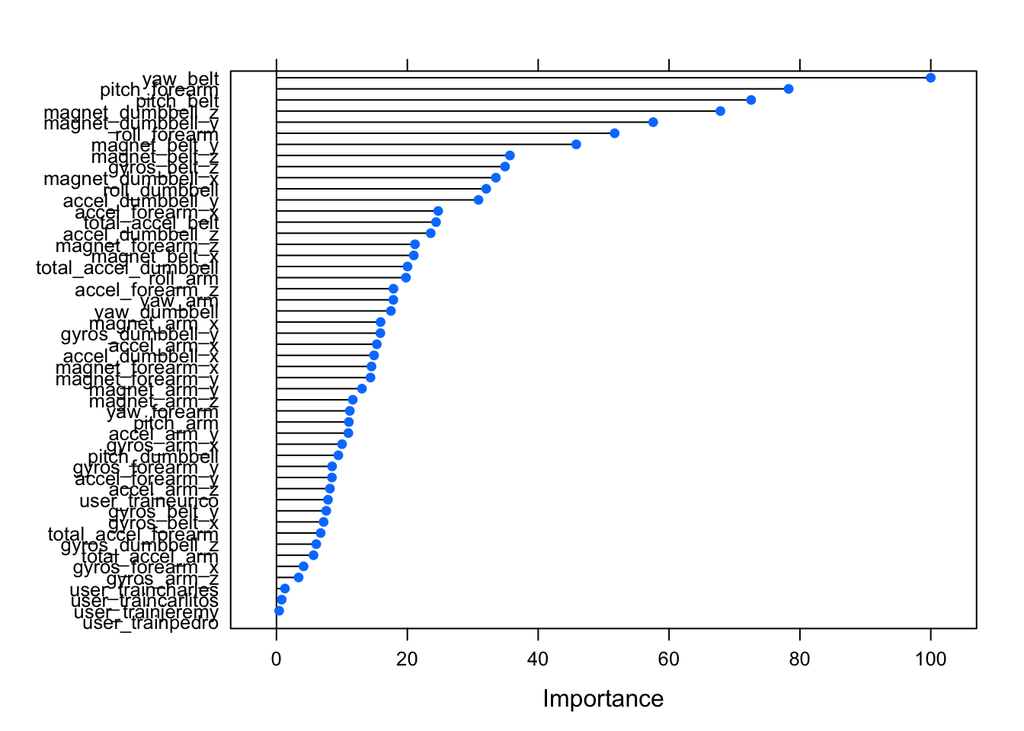

```r
plot(varImp(modfit))
```

```r
pred_test <- predict(modfit, test_v1)
pred_test
```

```
##  [1] B A B A A E D B A A B C B A E E A B B B
## Levels: A B C D E
```

We see from the variable importance chart that certain variable were more useful than others in predicting. Some further cleaning of the dataset could reduct processing time. Interestingly, the user was not very useful at all.

The data used in the exercise is from the following source: Velloso, E.; Bulling, A.; Gellersen, H.; Ugulino, W.; Fuks, H. Qualitative Activity Recognition of Weight Lifting Exercises. Proceedings of 4th International Conference in Cooperation with SIGCHI (Augmented Human ’13) . Stuttgart, Germany: ACM SIGCHI, 2013. Read more: http://groupware.les.inf.puc-rio.br/har#ixzz3vCLYcven